# Sahel Aedes+ Global Collaborative Network Meeting: September 9-12 2024

James Fifer

2024-09-09

## Introduction to R and terminal environments, using these environments to analyze sanger data and leverage fastngsadmix on WGS data

### Overview

In this tutorial we will go over some basics in R, process Sanger data and learn how to use FastNGSadmix to identify Ae. aegypti aegpyti and Ae. aegypti formosus on low coverage WGS. You can find the folder with all the necessary info here https://github.com/jamesfifer/Sahel_Mosquito_Network, go ahead and download the folder named Princeton2024WS. We will be switching between terminal and r environments, I’ve tried to color coordinate the code so that terminal is blue and R is always grey.

#### Outline

- Terminal environment explained
- Installing packages
- Rstudio environment explained
- Working with Sanger data in Rstudio
- Installing packages
- fastNGSadmix

### Day 1: Terminal Introduction

If you are using a Mac you can open your terminal by searching “terminal”, if you are using windows then download MSYS2 https://www.msys2.org/. Your terminal will look something like this:

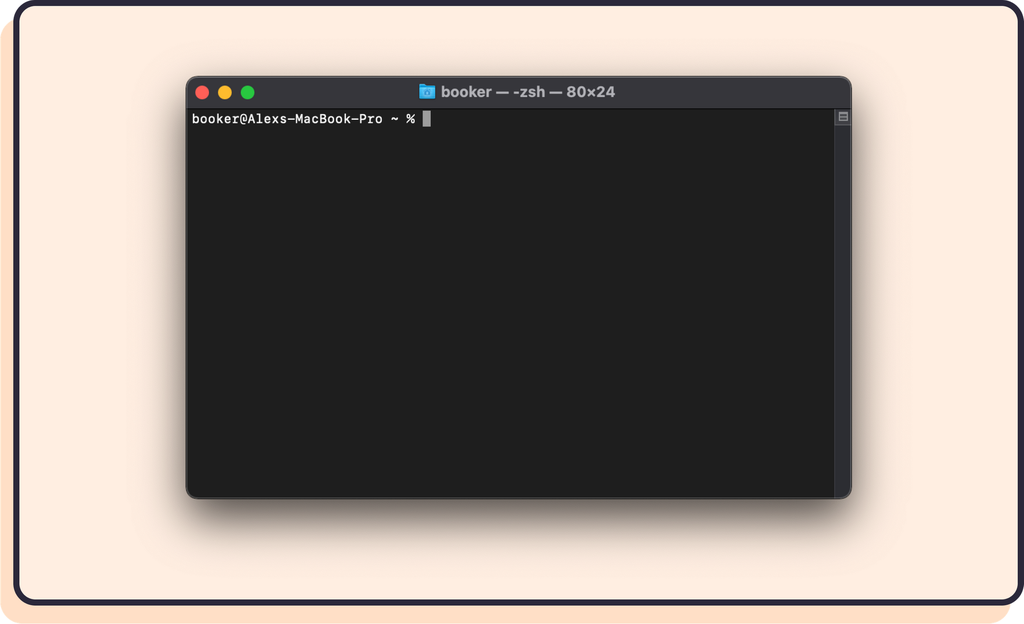

We will go over some basic commands in your terminal. First lets use the “pwd” command to figure out where we are.

```bash
pwd
```

The “pwd” command prints your current directory. We can also view all the folders and files in your directory by doing:

```bash
ls -lh
```

Notice folders have a “/” after their name (.e.g. “Desktop/”) We can move between directories using the command “cd”. Choose some folder and move into it!

```bash
cd yourfoldername/
```

You can use absolute paths (the entire directory name) or relative paths to move between folders. The relative path requires you to know where a folder is relative to your current position (we just did an example of a relative path). Here’s another example of using a relative path to move around. If you want to move one directory up just do

```bash
cd ..
```

If you want to use an absolute path try adding the directory that was printed when you ran “pwd” previously

```bash
cd /your/entire/path/here
```

If you know where you saved the Princeton2024WS folder go ahead and cd to that location. If you dont know where it is you can use the “find” function.

```bash
find / -type d -name "Princeton2024WS"
```

Once you find the folder go ahead and unzip it

```bash
unzip Princeton2024WS*
```

At any point if you get some permissions error you can try using the command “sudo”. This gives you admin privileges and will prompt you for your password.

### Installing necessary programs for the workshop

**Download Rstudio and R**

use the following link and follow instructions for your operating system https://posit.co/download/rstudio-desktop/

**Download FastNGSAdmix**

For *linux* Open terminal.

```bash
git clone https://github.com/e-jorsboe/fastNGSadmix.git;
cd fastNGSadmix
make
```

For *Macs* Try the same instructions as above for linux. If you dont have git or make installed you can install using homebrew

```bash
brew install git make
```

If you dont have homebrew you can install that first.

```bash
/bin/bash -c "$(curl -fsSL https://raw.githubusercontent.com/Homebrew/install/HEAD/install.sh)"
```

Follow the instructions that say “next steps” after installing homebrew

For *windows* Its going to be a little more complicated so get ready:)

Download MSYS2 https://www.msys2.org/. Pay attention to where you install ideally it would be C:/msys64 Open terminal and update package database

```bash
pacman -Syu
```

download relevant compilers

```bash
pacman -S mingw-w64-x86_64-gcc mingw-w64-x86_64-zlib
```

make sure it worked

```bash
pacman -Q | grep mingw-w64
```

check where this downloaded and ensure it is in your path

```bash
g++ --version
```

^If this worked you can skip the next step otherwise do

```bash
ls /mingw64/bin/g++
```

and insert this path into your .bashrc file

```bash
cd ~
nano .bashrc
```

Add the text: export PATH=/c/msys64/mingw64/bin:$PATH close nano

```bash
source ~/.bashrc
```

download “make” function

```bash
pacman -S make
```

download git and fastNGSadmix

```bash
pacman -S git
cd /c/msys64/mingw64/bin/
git clone https://github.com/e-jorsboe/fastNGSadmix.git;
cd fastNGSadmix
make
```

Now fastNGSadmix should be downloaded, you can do the following to save the path

```bash
pwd
```

**Download angsd**

Download htslib and angsd from github

```bash
git clone --recurse-submodules https://github.com/samtools/htslib.git;
git clone https://github.com/angsd/angsd.git;
cd htslib
make
cd ../angsd
make HTSSRC=../htslib
```

Note you will likely need install homebrew, git and make as described above. If you get an error about the “find” command, it is likely because you dont have “find” installed and your OS uses “gfind” instead. To get around this error you can first make sure you have findutils

```bash
brew install findutils
```

Then replace the find command with gfind

```bash
sed -i 's/find/gfind/' Makefile
```

Depending on your default syntax you might get an error running the above code, if so you can try the following

```bash
sed -i '' 's/find/gfind/' Makefile
```

**Download NCBI’s BLAST**

use the following link and follow instructions for your operating system https://ftp.ncbi.nlm.nih.gov/blast/executables/blast+/2.10.0/ Make a note of the location where you installed BLAST

### Day 1: Introduction to the R environment

**What’s the difference between Rstudio and R?**

Rstudio is a GUI (graphical user interface) tool that runs the programming language R.

Familiarize yourselves with the four panes in Rstudio. Top left is where we write our scripts, it is a text editor. Bottom left is the console- where the code gets sent from the text editor (this is the R platform) and where our outputs appear. Top right panel contains the global environment where we can see all our variables Bottom right panel is a viewer pane where we see things like plots and function explanations.

**Commenting and running code**

click run or ctrl+enter to run a line or section of code. (Shortcut is highlight line of code, or put your cursor on a line of code and type ctrl+enter). Putting a “#” before a line will result in the code not running. You can use this to annotate what the code is actually doing I recommend annotating every time you do something new, explaining what the code does. I also recommend copying outputs of tests that appear in the console window and pasting them in your R script so it is saved. for example

```r
2+2+2 #summing up 2s
```

```
## [1] 6
```

You can assign an output to a variable, for example

```r
answer=2+2+2
answer
```

```
## [1] 6
```

Notice that a variable called “answer” has now appeared in your global environment. You can click that variable to view it.

Its not just numbers/equations, you can assign anything for a variable for example

```r
name="James Fifer"
famous_names=c("Barrack Obama","Mahatma Gandhi", "James Fifer")
```

^Note I used an underscore here instead of a space in famous_names. In coding languages, spaces are your enemy and underscores are your friend. Try running the code above with a space instead of an underscore and see what happens.

**Functions**

Functions in R are run with the function name followed by parentheses, e.g.

```r
sum()
```

```
## [1] 0
```

```r
sum(2,2)
```

```
## [1] 4
```

If you want to learn more about a function you can type

```r
?sum()
```

### Day 1: Download R packages for Sanger Analysis

https://www.bioconductor.org/packages/devel/bioc/vignettes/sangerseqR/inst/doc/sangerseqRWalkthrough.html#6_Parsing_Alleles

**Download the necessary packages and set your working directory**

First install BiocManager and some packages we will use later

```r
install.packages("BiocManager","seqinr")
```

And load the packages

```r
library(BiocManager)
library(seqinr)
library(ape)
```

Then install some additional packages using the “install” function of BiocManager

```r
install(c("sangerseqR","annotate", "msa"))
```

Load those packages

```r
library(sangerseqR)
library(annotate)
library(msa)
```

Set your working directory.

```r
setwd("C:/Users/james/Princeton2024WS")
```

^This is just an example, you should set your directory to wherever you have saved your files.

### Day 1: Reading and checking raw Sanger files

**Reading and checking raw Sanger files**

First we will create a variable that contains all the “.ab1” files. (.ab1 is the common file extension for raw sanger data)

```r
ab1.files = list.files(pattern = "\\.ab1$", full.names = TRUE)
ab1.files
```

```
## [1] "./KF_001_MIN3-M-InvE_InvE-Forward_B11.ab1"
## [2] "./KF_002_MIN3-Q-InvE_InvE-Forward_C11.ab1"
## [3] "./KF_003_NGY7-M-InvE_InvE-Forward_D11.ab1"
## [4] "./KF_004_NGY7-Q-InvE_InvE-Forward_E11.ab1"
## [5] "./KF_005_MIN8-M-InvF_InvF-Reverse_F11.ab1"
## [6] "./KF_006_MIN8-Q-InvF_InvF-Reverse_G11.ab1"
## [7] "./KF_007_NGY3-M-InvF_InvF-Reverse_H11.ab1"
## [8] "./KF_008_NGY3-Q-InvF_InvF-Reverse_A12.ab1"
```

Lets choose one of the .ab1 files first. Convert the ab1 file to a Sangerseq object using the sangerseq() function and inspect the structure of the data file

```r
Inversion=sangerseqR::read.abif("KF_001_MIN3-M-InvE_InvE-Forward_B11.ab1")
Inversionseq = sangerseq(Inversion)
str(Inversionseq)
```

```
## Formal class 'sangerseq' [package "sangerseqR"] with 7 slots
##   ..@ primarySeqID  : chr "From ab1 file"
##   ..@ primarySeq    :Formal class 'DNAString' [package "Biostrings"] with 5 slots
##   .. .. ..@ shared         :Formal class 'SharedRaw' [package "XVector"] with 2 slots
##   .. .. .. .. ..@ xp                    :<externalptr>
##   .. .. .. .. ..@ .link_to_cached_object:<environment: 0x000002c408a9c480>
##   .. .. ..@ offset         : int 0
##   .. .. ..@ length         : int 890
##   .. .. ..@ elementMetadata: NULL
##   .. .. ..@ metadata       : list()
##   ..@ secondarySeqID: chr "From ab1 file"
##   ..@ secondarySeq  :Formal class 'DNAString' [package "Biostrings"] with 5 slots
##   .. .. ..@ shared         :Formal class 'SharedRaw' [package "XVector"] with 2 slots
##   .. .. .. .. ..@ xp                    :<externalptr>
##   .. .. .. .. ..@ .link_to_cached_object:<environment: 0x000002c408a9c480>
##   .. .. ..@ offset         : int 0
##   .. .. ..@ length         : int 890
##   .. .. ..@ elementMetadata: NULL
##   .. .. ..@ metadata       : list()
##   ..@ traceMatrix   : int [1:11155, 1:4] 817 832 854 883 915 941 949 939 921 908 ...
##   ..@ peakPosMatrix : num [1:890, 1:4] 4 18 30 44 56 70 81 96 110 124 ...
##   ..@ peakAmpMatrix : int [1:890, 1:4] 104 1295 1162 467 926 1480 984 880 980 1281 ...
```

```r
Inversionseq@primarySeq
```

```
## 890-letter DNAString object
## seq: GTTCCCGACCTGACGGATCGATCGACGTGAGTCGCG...CGACTCTACCCAGAATTACGGAAAGAGACAAAAAAA
```

Here is an overview of the main elements of the Sangerseq object:

**primarySeqID** – Identification of the primary sequence

**primarySeq** – The most likely sequence based on the florescence pattern

**secondarySeqID** – Secondary sequence ID. Secondary calls may not be present, but can occur when there is a signal for more than one base pair

**secondarySeq** – The secondary sequence

**traceMatrix** – A matrix containing the normalized signals for A,C,G,T.

**peakPosMatrix** – A matrix containing the position of the maximum peak values for each base.

**peakAmpMatrix** A matrix containing the maximum peak amplitudes for each base.

We can view the chromatogram, showing either primary calls only or both primary and secondary calls

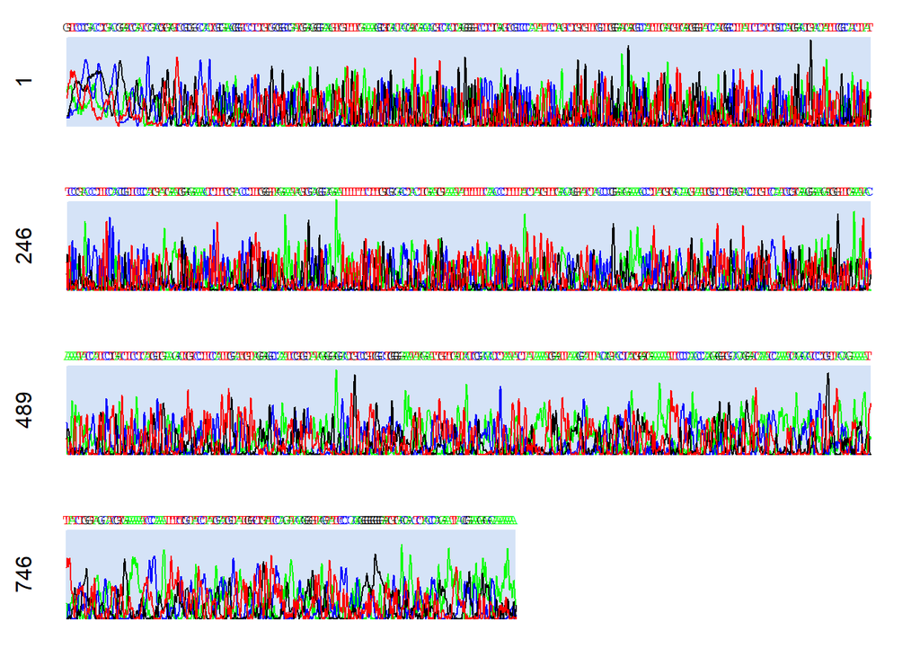

```r
chromatogram(Inversionseq, width = 250, height = 2, showcalls = "primary")
```

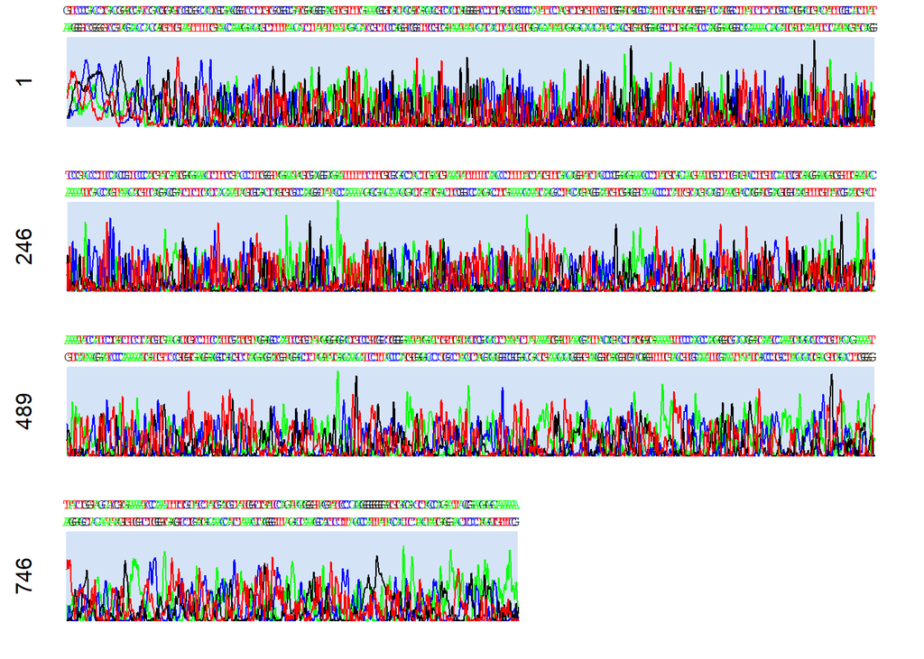

```r
chromatogram(Inversionseq, width = 250, height = 2, showcalls = "both")
```

We can visualize both primary and secondary calls. When heterozygous regions of the sequence are present, the makeBaseCalls can be used to determine whether a particular peak is homozygous or heterozygous and call the appropriate bases.

The makeBaseCalls function essentially divides the sequence into a series of basecall windows and identifies the tallest peak for each fluorescence channel within the window. These peaks are converted to signal ratio to the tallest peak. A cutoff ratio (i.e. the “ratio=” parameter below) is then applied to determine if a peak is signal or noise. Peaks below this ratio are ignored. Remaining peaks in each window are used to make primary and secondary basecalls.

```r
hetcalls = makeBaseCalls(Inversionseq, ratio = 0.5)
hetcalls
```

```
## Number of datapoints: 11155
## Number of basecalls: 890
##
## Primary Basecalls: ATTGGCGGGCATACGAAACGATCGGCGTGAGTCGCGGCTACTGCGACCAGCTCCTCTGCG…
##
## Secondary Basecalls: AARMGGWAAGCTYCGAATAGCGCCACGTGAGTCGAWTCTACGTAGCACKAAGACTATTTG…
```

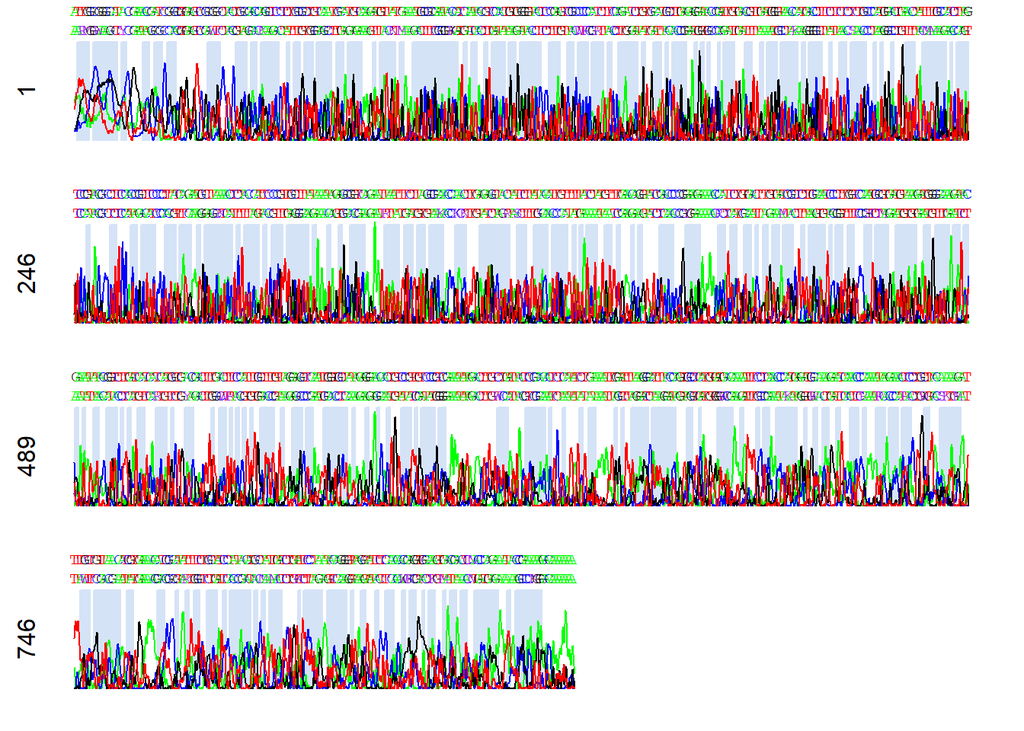

```r
chromatogram(hetcalls, width = 250, height = 2, showcalls = "both")
```

It is also possible to trim our data, here I give an example of trimming just the primary sequence, but you can apply the same logic to trim secondary calls as well.

First lets visualize what our sequences look like with some 5’ and 3’ trimming

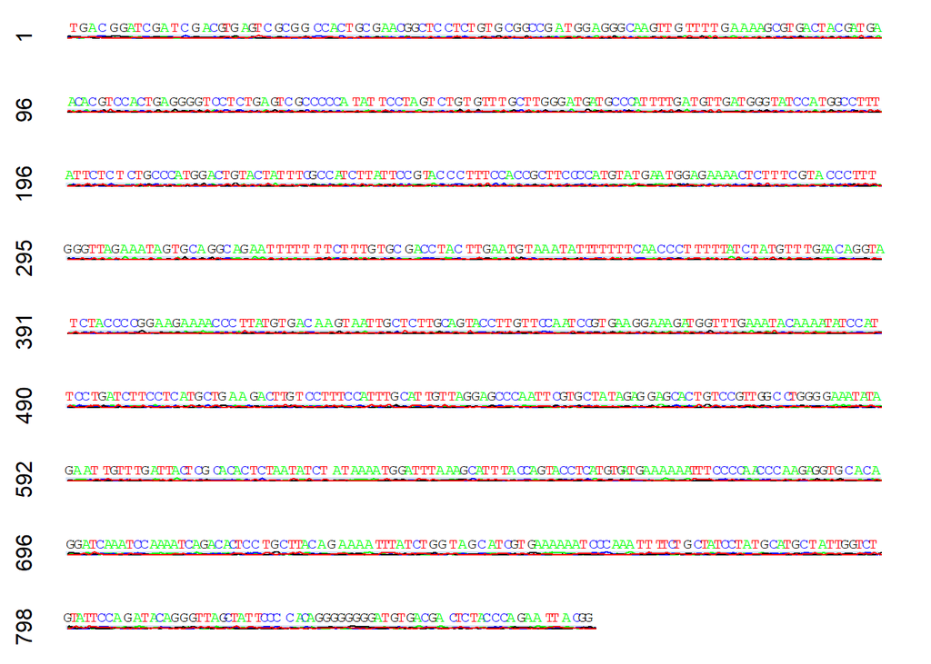

```r
chromatogram(Inversionseq, trim5 = 10, trim3 = 15)
```

Once we have located the region we want to trim, we can alter our primary sequence using the following code. Define the number of bases to trim

```r
trim5 = 10
trim3 = 15
```

Pull out the primary sequence and trim

```r
primarySeq = primarySeq(Inversionseq)
trimStart = trim5 + 1
trimEnd = nchar(primarySeq) - trim3
trimmedSeq = substr(primarySeq, trimStart, trimEnd)
Inversionseq_trimmed = new("sangerseq", primarySeq = trimmedSeq)
```

### Day 1: Analysis

**Using NCBI’s remote BLAST**

You can also blast your data to NCBI’s database. Here I provide example of searching the nr database. Lets work with our original Inversion sequence

```r
fasta_seq = DNAStringSet(hetcalls@primarySeq, use.names = TRUE)
```

Assign a name to the sequence, here we call it “hetcalls_primarySeq”

```r
names(fasta_seq) = "hetcalls_primarySeq"
```

Write the sequence to a FASTA file

```r
writeXStringSet(fasta_seq, filepath = "test.fasta")
```

#### BLAST

**Execute the following in your terminal, NOT R/Rstudio**

First locate where you installed your BLAST executables. Lets say they are located in “/c/Program Files/NCBI/blast-2.10.0+/bin” If you have no idea where you installed it you can run the following in your terminal

```bash
find / -name "blastx"
```

Once you have found the executable you have two options.

**Option 1** This is the simplest option. In order to run blast type the following in your **terminal**

```bash
/c/Program Files/NCBI/blast-2.10.0+/bin/blastx
```

(if you are running windows you will have to specify blast.exe):

```bash
/c/Program Files/NCBI/blast-2.10.0+/bin/blastx.exe
```

**Option 2** Add the executable to your PATH, this will allow you to use BLAST anywhere on your computer, but it can be a bit more difficult to setup.

```bash
nano ~/.bash_profile
```

Add the Directory to PATH: Add the following line to the file: export PATH=$PATH:“/c/Program Files/NCBI/blast-2.10.0+/bin” Save and Close: Save the file and close the editor (Ctrl + O to save, Ctrl + X to exit in nano). Reload the Profile: Reload the profile to apply changes:

```bash
source ~/.bashrc
```

Once we’ve set up the executable we can go ahead and run blast

```bash
blastx -query input.fasta -db nr -remote -out results.txt
```

Results will look something like this

BLASTX 2.10.0+

Reference: Stephen F. Altschul, Thomas L. Madden, Alejandro A. Schaffer, Jinghui Zhang, Zheng Zhang, Webb Miller, and David J. Lipman (1997), “Gapped BLAST and PSI-BLAST: a new generation of protein database search programs”, Nucleic Acids Res. 25:3389-3402.

Database: All non-redundant GenBank CDS translations+PDB+SwissProt+PIR+PRF excluding environmental samples from WGS projects 717,322,484 sequences; 276,785,072,227 total letters

Query= hecalls_primarySeq

Length=890

RID: CWFR8R6X016 Score E Sequences producing significant alignments: (Bits) Value

CAA82333.1 phosphatidylinositol 3-kinase [Homo sapiens] 45.8 7e-06 XP_020024197.1 phosphatidylinositol 4,5-bisphosphate 3-kinase cat… 45.8 5e-05

#### Aligning reads

**Going back to Rstudio for this section**

Lets say you have sanger data for multiple samples and you want to align the reads. We can first leverage many of the same functions that we previously did with our Inversion sequence. But first, lets view all samples with the extension “.ab1”

```r
ab1.files = list.files(pattern = "\\.ab1$", full.names = TRUE)
ab1.files
```

```
## [1] "./KF_001_MIN3-M-InvE_InvE-Forward_B11.ab1"
## [2] "./KF_002_MIN3-Q-InvE_InvE-Forward_C11.ab1"
## [3] "./KF_003_NGY7-M-InvE_InvE-Forward_D11.ab1"
## [4] "./KF_004_NGY7-Q-InvE_InvE-Forward_E11.ab1"
## [5] "./KF_005_MIN8-M-InvF_InvF-Reverse_F11.ab1"
## [6] "./KF_006_MIN8-Q-InvF_InvF-Reverse_G11.ab1"
## [7] "./KF_007_NGY3-M-InvF_InvF-Reverse_H11.ab1"
## [8] "./KF_008_NGY3-Q-InvF_InvF-Reverse_A12.ab1"
```

We can easily select just the Forward reads using the grep() function which which allows you to extract matches to some string (in this case “Forward”)

```r
forward_reads = grep("Forward", ab1.files, value = TRUE)
```

Now to create an empty list, iterate through the reads and fill the list with the sequences.

```r
sequences = list()
for (seq in (1:length(forward_reads))){
  print(forward_reads[seq])
  input=sangerseqR::read.abif(forward_reads[seq])
  inputseq = sangerseq(input)
  called=makeBaseCalls(inputseq, ratio = 0.5)
  primarycall=called@primarySeq
  sequences[[seq]]=primarycall
  names(sequences)[seq] =forward_reads[seq]
}
```

```
## [1] "./KF_001_MIN3-M-InvE_InvE-Forward_B11.ab1"
## [1] "./KF_002_MIN3-Q-InvE_InvE-Forward_C11.ab1"
## [1] "./KF_003_NGY7-M-InvE_InvE-Forward_D11.ab1"
## [1] "./KF_004_NGY7-Q-InvE_InvE-Forward_E11.ab1"
```

We’ve stored each sequence in the object “sequences”, now to convert to a DNAStringSet object so we can use the “msa” package that we installed earlier to align the sequences.

```r
stringsetseqs=DNAStringSet(sequences)
myAlignment = msa(stringsetseqs,method = "ClustalW")
```

```
## use default substitution matrix
```

```r
print(myAlignment, show="complete")
```

```
##
## MsaDNAMultipleAlignment with 4 rows and 998 columns
##     aln (1..54)                                            names
## [1] ---ATTGGCGGGCA-TACGAAACGATCGGCGTGAGTCGCGGCTACTGCGAC--C ./KF_001_MIN3-M-I...
## [2] --TATTGCCGTACGGTGTGAAGAAGCTCGAGTGTGTTAGCATTCCTCTGATGAC ./KF_002_MIN3-Q-I...
## [3] CCTTGTGCTGCGCGAGATAANGTCGCCGACGTGCCTCG-AGTCGTTAGCAGGAC ./KF_003_NGY7-M-I...
## [4] CATCGCCTTCCGCGTGCAAGTAGGCGCGACATGCCTCG-CATTCTTCTCCGCGC ./KF_004_NGY7-Q-I...
## Con ?-TA?TGC?GCGCG??AT?AA??GGCCG?CGTGC?TCG-C?TTC?TCT?AGGAC Consensus
##
##     aln (55..108)                                          names
## [1] AGCTCCT-CTGCGCTGTCAATG--CATGTCAAGATGTTATG-AAA-TGCGCGAA ./KF_001_MIN3-M-I...
## [2] GGTTGCT-CTGTGTTGGAGATAT-CAGGGCTAGATAATGAGCAAA-TGAGTGAA ./KF_002_MIN3-Q-I...
## [3] GGTTGTT-CTGTGTCCGGAACACCCTTGNNTATTTGTCGCC-CAC-CGAGTGAA ./KF_003_NGY7-M-I...
## [4] GGCCGCCACCGCGGTGGAGCACCCATTCGCCTTATGATGAGCCGCATCACTGAT ./KF_004_NGY7-Q-I...
## Con GG?TGCT-CTG?GTTGGA?ATAC?C?TGGCTA?ATG?TGAG??A?-TGAGTGAA Consensus
##
##     aln (109..162)                                         names
## [1] TACCATCAATACGTCCACTGTGGGGTACTCCGAGTCGCCCCCATC-TTCCAGA- ./KF_001_MIN3-M-I...
## [2] TGCGAGCAATACTTCCTAAATGAATTCCTGGGAATCACTGNCAAT-ACTCAGAA ./KF_002_MIN3-Q-I...
## [3] TNGGTACTAC-CTTTGTCTATGAATTACTGGAAGTCACTNGCAACATCTCATAG ./KF_003_NGY7-M-I...
## [4] NACGGGCCGTCGTTTGNTTCTGAAAGACTGGGAGACCCTGGCGTTACCCTACAT ./KF_004_NGY7-Q-I...
## Con TACGAGCAATACTT??TCTATGAATTACTGGGAGTCACTGGCA???TC?CAGA? Consensus
##
##     aln (163..216)                                         names
## [1] TCTGTGC-ATGCTTGAGAGGATACCGATTGTGACGTTG-ATGGGTAACCATGAC ./KF_001_MIN3-M-I...
## [2] CCTGTTCTAGGCTAGATACGATGCCCGATTTGACGTTG-ATGGATAAAGATGTC ./KF_002_MIN3-Q-I...
## [3] CAGGTTCTACGCTAGATCCTCTCTCCGAGATCACTGAG-GATGATAATTATGTT ./KF_003_NGY7-M-I...
## [4] AATGGGCTAGCCTTTCGAATGTCTCCAGTGTCCTGGTATGATTGTAATTATGGC ./KF_004_NGY7-Q-I...
## Con C?TGT?CTAGGCT?GA?AC?ATC?CC?ATGT?ACG?TG-???G?TAATTATGTC Consensus
##
##     aln (217..270)                                         names
## [1] CTTTCTTCTC-TCTGCCCATGGACTGAAC-TATTTTGCCATCTTAGTCCGTACG ./KF_001_MIN3-M-I...
## [2] CTTTGTTCTCGCCTGCCCATGGGCTGTTC-TACCCCGCCATCTCATTCCAAACT ./KF_002_MIN3-Q-I...
## [3] CTTTGGAATCACAGACTCTTTGGTGGAAC-TATCTCAGAAATTCGACCCGAATT ./KF_003_NGY7-M-I...
## [4] CTTCCCGATCGCCCCTCCCTTGACAAAAGATTCCTGAAGAGATTGGGGGGCACG ./KF_004_NGY7-Q-I...
## Con CTTT?TT?TCGCCTGCCCAT?G?CTGAAC-TA?CTC?CCATCT??GTCCGAAC? Consensus
##
##     aln (271..324)                                         names
## [1] CCTT-CCACCGCTTCCCCTTAT-CAGAATGCTTAAAACTCTACCATTCCCGTTG ./KF_001_MIN3-M-I...
## [2] CCTTGCCACTGCTACACCGAATTCTGAATGGAAAATCATCTACATGTATTGCTT ./KF_002_MIN3-Q-I...
```

[output cut: 79 more lines]

```
## Con CCTT??GC?-AGAGATAGCTA?ACCC?CC?CC?GGG?A?GGC?A???CTT?AAC Consensus
##
##     aln (919..972)                                         names
## [1] CAGAAATACCGAAAAA--GACAAAAAAA-------------------------- ./KF_001_MIN3-M-I...
## [2] TATGAATCCCGGACATTTGACTAAGAATACTTTTAACACTTCTGACACATATCT ./KF_002_MIN3-Q-I...
## [3] ------------------------------------------------------ ./KF_003_NGY7-M-I...
## [4] ACGGTGTTTTTTNGGAAGAACACATAANAAAAC--------------------- ./KF_004_NGY7-Q-I...
## Con ?AGGAAT?CCG?A?AA--GACAAA?AA??------------------------- Consensus
##
##     aln (973..998)             names
## [1] -------------------------- ./KF_001_MIN3-M-I...
## [2] ACCTCGAATNAGTTACAGGAAAATTT ./KF_002_MIN3-Q-I...
## [3] -------------------------- ./KF_003_NGY7-M-I...
## [4] -------------------------- ./KF_004_NGY7-Q-I...
## Con -------------------------- Consensus
```

Time to make a tree! Here we use the “seqinr” and “ape” packages that we installed earlier

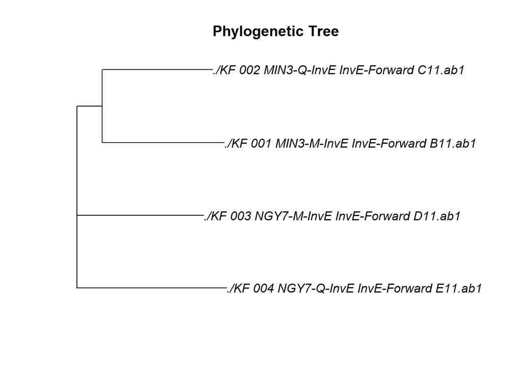

```r
seqinrAln = msaConvert(myAlignment, type="seqinr::alignment")
d = dist.alignment(seqinrAln, "identity")
hemoTree = nj(d)
plot(hemoTree, main="Phylogenetic Tree")
```

#### Extras

Check out the package sangeranalyseR if you have forward and reverse reads that you want to first assemble.

### Day 2: FastNGSADMIX

FastNGSADMIX is a tool to quickly and reliably estimate admixture proportions and perform PCA from next generation sequencing data of a single individual. The analyses are based on genotype likelihoods of the input sample and a set of predefined reference populations. This method is particularly useful because of its high accuracy and speed, even at low sequencing depth and corrects for the biases introduced by small reference populations. You can find more information about the program [here](https://academic.oup.com/bioinformatics/article/33/19/3148/4060550).

We can use a marker set of loci developed from Rose 2020 that can estimate genetic ancestry belonging to Aedes aegypti aegypti, Eastern Ae. aegypti formosus and Western Ae. aegypti formosus.

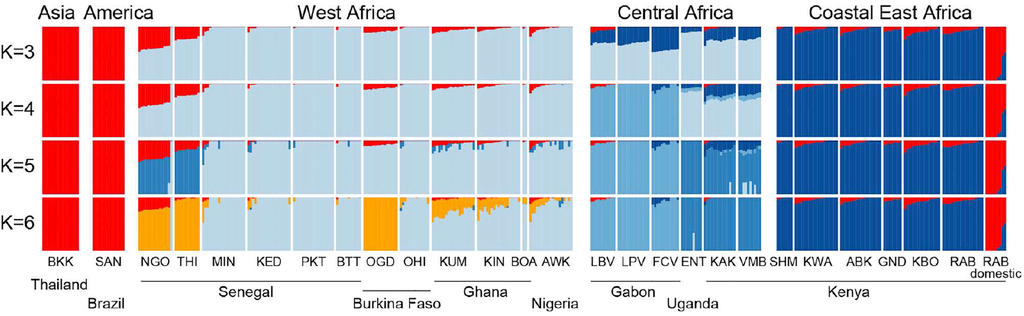

Admixture plot of Aedes aegypti showing three different genetic ancestries corresponding to Aedes aegypti aegypti and two lineages of Aedes aegypti formosus (East and West)

In order to run fastngsadmix, we need to go back to using our *terminal*. We will use angsd to estimate genotype likelihoods and then run fastngsadmix on the informative genetic loci to get estimates of genetic ancestry. We do this for each sample.

Before we run the code lets take a look at the files we have. You can do:

```bash
head filenamehere
```

to see the first few rows of each file.

#### fastngsadmix files

- rose2020panel.3.chrom.sites- A file with chromosome and base pair position as well as information on the major and minor alleles. This allows us to tell angsd to create genotypic information for only the sites that we actually care about (in other words saves time).
- fastadmixtest- A file that contains the filenames for every “.bam” files (.bam files are our alignment files that we get after mapping sequencing data to a reference)
- rose2020panel.3.chrom.txt- Our panel file that include locus information, reference and alternative alleles as well as a measure of the prevalence of the reference allele in each of the three ancestral populations (aegypti aegpyti, eastern formosus or western formosus).
- rose2020panel.3.nind.txt- These are the number of individuals that were initially used to generate info for each of the ancestral populations.

Ok now we can run the following code (should take between 30 mins and an hour)

```bash
>runfastmix
while read i; do
CURR=$(basename "$i" .bam);
echo -e "/path/to/program/angsd -i $i -GL 2 -sites rose2020panel.3.chrom.sites -doGlf 2 -doMajorMinor 3 -minMapQ 10 -minQ 20 -doDepth 1 -doCounts 1 -P 2 -out $CURR && /path/to/program/fastNGSadmix -likes ${CURR}.beagle.gz -fname rose2020panel.3.chrom.txt -Nname rose2020panel.3.nind.txt -out $CURR -whichPops all &"; done < fastadmixtest> runfastmix
echo "wait" >> runfastmix
```

This generates .qopt files for each sample. We can combine these files into one using the following code:

```bash
input="fastadmixtest"
output="fastadmixtest.qopt"

ls *.qopt | head -n 1 | xargs head -n 1 > "${output}.header.tmp"
# Step 2: Create a temporary file for concatenated data
> "${output}.data.tmp"
# Step 3: Read each line from the input file and append the content of the corresponding .qopt file (excluding the first line) to the temporary data file
while read -r line; do
    tail -n +2 "${line%.bam}.qopt" >> "${output}.data.tmp"
done < "$input"
# Step 4: Combine the header with the concatenated data
cat "${output}.header.tmp" "${output}.data.tmp" > "${output}.final.tmp"
# Step 5: Create a file with the word "adapter"
echo "adapter" > "${output}.otherheader.tmp"
# Step 6: Add "adapter" to the beginning of the input file and save it as a temporary adapter file
cat "${output}.otherheader.tmp" "$input" > "${output}.adapter.tmp"
# Step 7: Combine the header with the concatenated data and save it to the final output file
paste "${output}.adapter.tmp" "${output}.final.tmp" > "$output"
```

Once we have this fastadmixtest.qopt file we can go back in *R* and summarize the data

```r
meta=read.table(file="Metadata.txt")
fast=read.table(file="fastadmixtest.qopt",header=T,sep="", fill=T)
merged_df = merge(fast, meta, by = "adapter")
head(merged_df)
```

```
##                                     adapter   AafW   AafE    Aaa POP indv
## 1  merged.SAHEL.B1.dedup.overlapclipped.bam 0.8458 0.0000 0.1542 OSG 5025
## 2 merged.SAHEL.B10.dedup.overlapclipped.bam 0.7605 0.0000 0.2395 DRI 5091
## 3 merged.SAHEL.B11.dedup.overlapclipped.bam 0.8207 0.0380 0.1413 DRI 5092
## 4  merged.SAHEL.B2.dedup.overlapclipped.bam 0.8720 0.0001 0.1279 ZDR 5081
## 5  merged.SAHEL.B7.dedup.overlapclipped.bam 0.8079 0.0808 0.1113 DRI 5088
## 6  merged.SAHEL.B9.dedup.overlapclipped.bam 0.8341 0.0302 0.1357 DRI 5090
##   Latitude  Longitude
## 1 15.60150 -13.320400
## 2 14.03540  -0.034500
## 3 14.03540  -0.034500
## 4 13.81073   8.986147
## 5 14.03540  -0.034500
## 6 14.03540  -0.034500
```

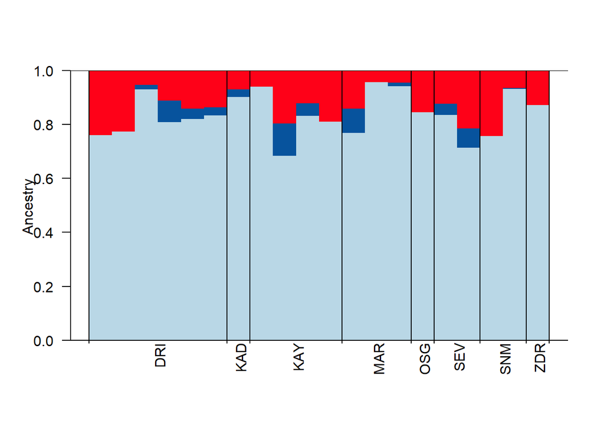

```r
tbl=(merged_df[c(2:6)])
colnames(tbl)[c(4,5)]=c("pop","ind")
tbl$ind=as.factor(tbl$ind)
tbl$pop=as.factor(tbl$pop)
colors=c("#b9d7e6ff","#07539dff","#fe0118ff")
source("plot_admixture_v5_function.R")
ords=plotAdmixture(data=tbl,npops=3,grouping.method="distance",vshift=-.1,hshift=-3,colors = colors)
```

### Day 2: Creating a map in R

There are lots of ways to make maps in R, I’ve found just using the base R plot functions and then building custom functions is the easiest for me. First lets download some more packages

```r
library(raster)
library(geodata)
library(plotrix)
library(dplyr)
```

Then we will take the admixture means for each population

```r
obs_data = merged_df %>%
  group_by(POP) %>%
  summarize(
    Latitude = mean(Latitude, na.rm = F),
    Longitude = mean(Longitude, na.rm = F),
    Aaa = mean(Aaa, na.rm = F),
    AafE = mean(AafE, na.rm = F),
    AafW = mean(AafW, na.rm = F)
  )
```

Assign minimum and maximum values for the map based on geographic coordinates for the samples

```r
max_lat = ceiling(max(obs_data$Latitude))
min_lat = floor(min(obs_data$Latitude))
max_lon = ceiling(max(obs_data$Longitude))
min_lon = floor(min(obs_data$Longitude))
geographic_extent = extent(x = c(min_lon, max_lon, min_lat, max_lat))
```

Download worldmap data and then plot. Lets add in some pie charts, adjust the radius and jitters as needed

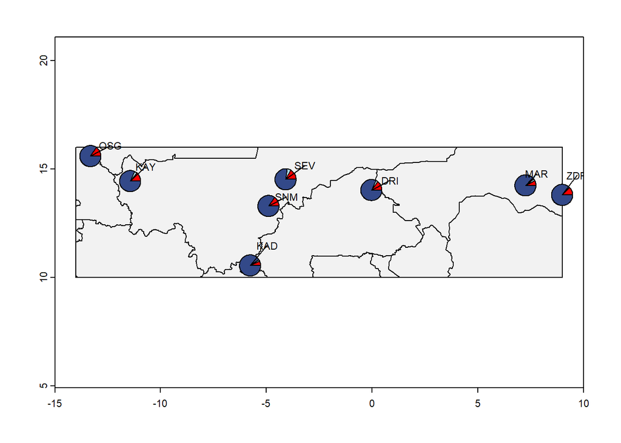

```r
world_map = world(resolution = 3,
                   path = "data/")
my_map = crop(x = world_map, y = geographic_extent)
plot(my_map, axes = TRUE, col = "grey95", xlim = c(min_lon - 1, max_lon + 1), ylim = c(min_lat - 1, max_lat + 1))
colors = c("red", "lightblue","#334989ff")
for (i in 1:nrow(obs_data)) {
  segments = c(obs_data$Aaa[i], obs_data$AafE[i],obs_data$AafW[i])
    floating.pie(
    xpos = obs_data$Longitude[i],
    ypos = obs_data$Latitude[i],
    x = segments,
    radius = .5,
    col = colors
  )
}

for (i in 1:nrow(obs_data)) {
  label_x = obs_data$Longitude[i] + runif(1, 0.4, 1)  # Jitter x further away
  label_y = obs_data$Latitude[i] + runif(1, 0.4, 1)    # Jitter y further away

  # Draw a line from the pie chart to the label
  segments(
    x0 = obs_data$Longitude[i], y0 = obs_data$Latitude[i],  # Start at pie chart
    x1 = label_x, y1 = label_y,  # End at label position
    col = "black"
  )
  # Add the label at the end of the line
  text(
    x = label_x,
    y = label_y,
    labels = obs_data$POP[i],
    cex = 0.7,  # Adjust text size as needed
    col = "black"
  )
}
```